# Assignment #1 -- Data Preprocessing and Visualization

**Questions to Address:**

1. Calculate the average SRT of every 10 minutes, and plot the SRT with a **line chart** (x axis for date time and y axis for the average SRT).
2. Calculate the average of each SRT component of every 10 minute, and plot the four SRT components together with a **stacked area chart** (x axis for date time and y axis for time) and also a **100% stacked area chart** (y axis for the percentage).
3. Plot the **CDF (Cumulative distribution function) chart** of SRT.
4. Plot the **CDF chart** of #Images.
5. Count the number of queries (also called page views or PVs) of each minute, and plot the minute-level PVs with a **line chart** (x axis for date time and y axis for the PVs).
6. Count the PVs of each province, and plot it with a **histogram chart** (x axis for province and y axis for PVs).
7. Count the PVs of each UA, and plot it with a **pie chart** (show the percentages in the chart).
8. What are the differences among those charts (How to decide which one to use)
9. Describe your experience or findings in doing those jobs. For example, experience of processing the data, observations from the charts, characteristics of the data, potential explanations, and any interesting things you would like to mention.

## Import libraries and dependencies

## Data Preprocessing

```
The combined dataframe has 4961926 rows and 12 columns
```

|  | Timestamp | #Images | UA | Ad | ISP | Province | PageType | Tnet | Tserver | Tbrowser | Tother | SRT |
| --- | --- | --- | --- | --- | --- | --- | --- | --- | --- | --- | --- | --- |
| 0 | 2014-09-21 16:00:00 | 37 | MSIE 8+ | noAD | CHINANET | Zhejiang | async | 371.0 | 97.0 | 251.0 | 223.0 | 942.0 |
| 1 | 2014-09-21 16:00:00 | 12 | MSIE 8+ | noAD | CHINANET | Zhejiang | async | 67.0 | 506.0 | 155.0 | 257.0 | 985.0 |
| 2 | 2014-09-21 16:00:00 | 24 | Chrome | noAD | CMNET | Jiangsu | async | 90.0 | 228.0 | 33.0 | 799.0 | 1150.0 |
| 3 | 2014-09-21 16:00:00 | 18 | MSIE 8+ | noAD | OTHER | Beijing | async | 30.0 | 132.0 | 25.0 | 46.0 | 233.0 |
| 4 | 2014-09-21 16:00:00 | 13 | Chrome | noAD | UNICOM | Beijing | async | 29.0 | 491.0 | 28.0 | 46.0 | 594.0 |

```
<class 'pandas.core.frame.DataFrame'>
RangeIndex: 4961926 entries, 0 to 4961925
Data columns (total 12 columns):
 #   Column     Dtype
---  ------     -----
 0   Timestamp  datetime64[ns]
 1   #Images    uint8
 2   UA         category
 3   Ad         category
 4   ISP        category
 5   Province   category
 6   PageType   category
 7   Tnet       float64
 8   Tserver    float64
 9   Tbrowser   float64
 10  Tother     float64
 11  SRT        float64
dtypes: category(5), datetime64[ns](1), float64(5), uint8(1)
memory usage: 255.5 MB
```

|  | #Images | Tnet | Tserver | Tbrowser | Tother | SRT |
| --- | --- | --- | --- | --- | --- | --- |
| count | 4961926.000000 | 4961926.000000 | 4961926.000000 | 4961926.000000 | 4961926.000000 | 4961926.000000 |
| mean | 19.838922 | 226.426128 | 248.436270 | 103.883344 | 367.956266 | 946.702008 |
| std | 11.786021 | 377.684353 | 209.105566 | 167.733417 | 592.464142 | 810.273467 |
| min | 0.000000 | 0.000000 | 1.000000 | 0.000000 | 0.000000 | 11.000000 |
| 25% | 12.000000 | 59.000000 | 122.000000 | 31.000000 | 57.000000 | 449.000000 |
| 50% | 22.000000 | 127.000000 | 194.000000 | 55.000000 | 172.000000 | 694.000000 |
| 75% | 28.000000 | 240.000000 | 335.000000 | 110.000000 | 390.000000 | 1105.147500 |
| max | 245.000000 | 4943.000000 | 4721.000000 | 4844.000000 | 4902.000000 | 5000.000000 |

## Chart Generations

#### Calculate the average SRT of every 10 minutes, and plot the SRT with a **line chart** (x axis for date time and y axis for the average SRT).

**Analysis:** From the line chart, we observe that the trend seems to repeat across same-time-different-days. For instance, during the early morning hours, the SRT would be lower. However, the SRT would peak in the mid-day (towards the evening).

Therefore, from the perspective of the search engine, we should consider using a time-series forecasting approach if we want to do prediction for the SRT. However, the changes in these values could be due to a myriad of reasons - e.g. due to the SRT components, or due to other variables. Therefore, we should breakdown the SRT into components and perform further analysis.

|  | Timestamp | SRT |
| --- | --- | --- |
| 0 | 2014-09-21 16:00:00 | 906.536375 |
| 1 | 2014-09-21 16:10:00 | 895.643628 |
| 2 | 2014-09-21 16:20:00 | 876.467753 |
| 3 | 2014-09-21 16:30:00 | 892.630692 |
| 4 | 2014-09-21 16:40:00 | 874.951058 |
| ... | ... | ... |
| 2011 | 2014-10-05 15:10:00 | 939.203427 |
| 2012 | 2014-10-05 15:20:00 | 932.823204 |
| 2013 | 2014-10-05 15:30:00 | 933.241116 |
| 2014 | 2014-10-05 15:40:00 | 893.709013 |
| 2015 | 2014-10-05 15:50:00 | 884.702217 |

2016 rows × 2 columns

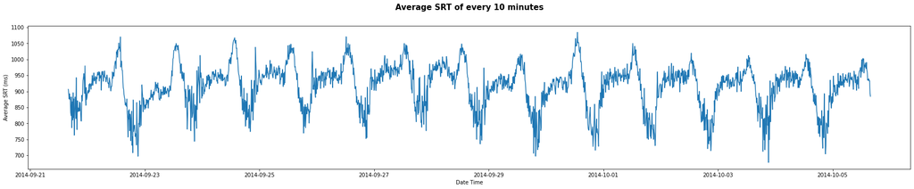

#### Calculate the average of each SRT component of every 10 minute, and plot the four SRT components together with a **stacked area chart** (x axis for date time and y axis for time) and also a **100% stacked area chart** (y axis for the percentage).

**Analysis:** From the stacked area chart, we notice that the overall trend for all the components are similar (e.g. when Tnet increases, the Tserver, Tbrowser and Tother are likely to increase). It appears that there exist a form of correlation between them. Additionally, the trend seems to repeat across same-time-different-days.

Therefore, from the perspective of the search engine, we should consider using a time-series forecasting approach if we want to do prediction for the SRT components. The correlation between each component could also suggest that the SRT values could be correlated to other factors such as number of page views per minute, etc. Therefore, we should perform further analysis subsequently.

Thus, from the perspective of the search engine, if we want to reduce the SRT, we should explore what reasons would fall under Tother and fix them. Otherwise, reinspecting our network structure / architecture and our server's CPU and utilisation could be a viable approach.

|  | Timestamp | Tnet | Tserver | Tbrowser | Tother |
| --- | --- | --- | --- | --- | --- |
| 0 | 2014-09-21 16:00:00 | 240.866494 | 231.211210 | 113.980551 | 320.478120 |
| 1 | 2014-09-21 16:10:00 | 234.484759 | 227.134765 | 107.037701 | 326.986403 |
| 2 | 2014-09-21 16:20:00 | 207.013556 | 227.753990 | 116.294969 | 325.405238 |
| 3 | 2014-09-21 16:30:00 | 223.563776 | 223.181509 | 110.717230 | 335.168178 |
| 4 | 2014-09-21 16:40:00 | 236.600108 | 225.313283 | 110.222422 | 302.815247 |
| ... | ... | ... | ... | ... | ... |
| 2011 | 2014-10-05 15:10:00 | 229.920329 | 230.923232 | 85.918161 | 392.441704 |
| 2012 | 2014-10-05 15:20:00 | 233.887532 | 228.578472 | 90.022400 | 380.334800 |
| 2013 | 2014-10-05 15:30:00 | 224.649388 | 224.712534 | 91.997483 | 391.881711 |
| 2014 | 2014-10-05 15:40:00 | 209.457376 | 225.850112 | 84.538807 | 373.862719 |
| 2015 | 2014-10-05 15:50:00 | 217.957177 | 219.244770 | 86.809627 | 360.690644 |

2016 rows × 5 columns

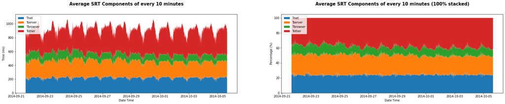

#### Plot the **CDF (Cumulative distribution function) chart** of SRT.

**Analysis:** From the PDF, we can see that the distribution of SRT is ideal, where most are centered around 468.0ms. The long right-tail is normal due to network latency issues.

From the search engine perspective, we would want to achieve 2 goals.

1. **Minimise SRT in general (the centre of distribution)**

   This calls for us to improve our overall infrastructure - be it hardware (via cable laying) or architectural (redesigning the network routes and connections)
2. **Reduce the occurences where SRT is extremely long (in the long right-tail)**

   This calls for us to redesign our software approaches to handle such cases (e.g. inspecting our network traffic algorithms in nodes)

##### Using sns.distplot (visually clearer and simpler code but slower)

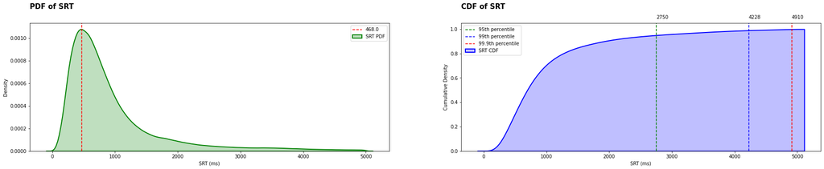

##### Pure Pandas Approach without sns.distplot (visually less clear and more code but faster)

**Analysis:** Same as above. This approach is just a faster approach, especially useful if we have an even larger dataset to process.

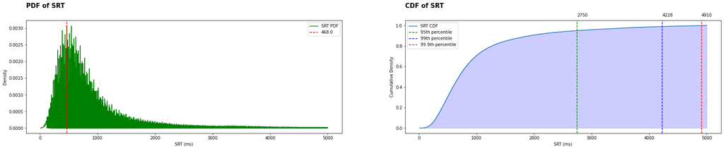

#### Plot the **CDF chart** of #Images.

**Analysis:** From the PDF, we can see that most webpages have 0, around 12, around 25 images embedded. From the CDF, we can visibly see that the 99th percentile covers 46 while the 99.9th percentile covers 67 images.

From the search engine perspective, if we want to optimise our search / query speed, the above statistics come in handy. For example, if our policy is to render 99.9% of all queries in a fix / benchmarked amount of time, we should aim to be able to render 67 images per query. However, if our policy is slightly more lenient, or if we do not have the required infrastructure or capabilities, we can settle for 46 images, which covers 99% of all queries.

##### Using sns.distplot (visually clearer and simpler code but slower)

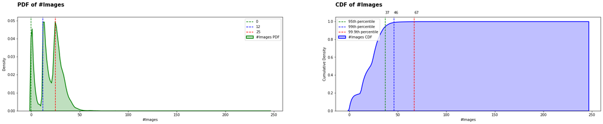

##### Pure Pandas Approach without sns.distplot (visually clear and faster but more code)

**Analysis:** Same as above. This approach is just a faster approach, especially useful if we have an even larger dataset to process.

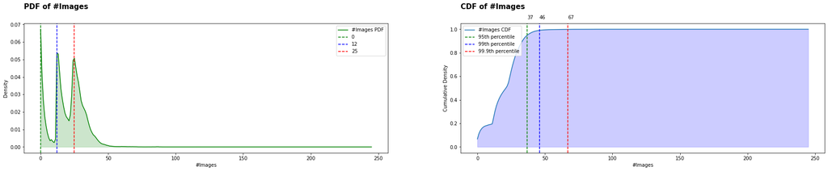

#### Count the number of queries (also called page views or PVs) of each minute, and plot the minute-level PVs with a **line chart** (x axis for date time and y axis for the PVs).

|  | Timestamp | PV |
| --- | --- | --- |
| 0 | 2014-09-21 16:00:00 | 190 |
| 1 | 2014-09-21 16:01:00 | 209 |
| 2 | 2014-09-21 16:02:00 | 173 |
| 3 | 2014-09-21 16:03:00 | 193 |
| 4 | 2014-09-21 16:04:00 | 184 |
| ... | ... | ... |
| 20154 | 2014-10-05 15:54:00 | 202 |
| 20155 | 2014-10-05 15:55:00 | 222 |
| 20156 | 2014-10-05 15:56:00 | 209 |
| 20157 | 2014-10-05 15:57:00 | 188 |
| 20158 | 2014-10-05 15:58:00 | 190 |

20159 rows × 2 columns

##### Plot without smoothening (Visually distracting due to jitters)

Distracts audience from focusing on the overall trends, rather than the jitters

**Analysis:** There can be large fluctuations in terms of page visits across minutes. Therefore, from the perspective of the search engine, our infrastructure must be able to scale quickly and dynamically on-demand. This could warrant for us to establish an SRE team to look into optimisation techniques for low-cost rapid scaling.

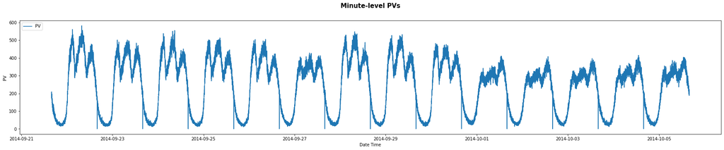

##### Plot with smoothening (Visually clearer)

Draws audience focus on the overall trends (per hour instead of per minute), by smoothening the jitters

**Analysis:** In terms of general trend, we can see that PV peaks during the mid-day and tapers during the late night. From the perspective of the search engine, our infrastructure team can implement auto-scaling features based on ML models with time-series forecasting approaches. This could capture the pattern more easily and may be a more robust approach than to scale purely on-demand.

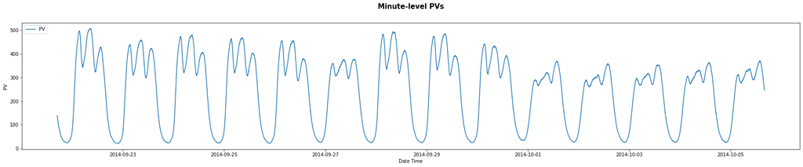

#### Count the PVs of each province, and plot it with a **histogram chart** (x axis for province and y axis for PVs).

|  | Province | PV |
| --- | --- | --- |
| 0 | Guangdong | 605835 |
| 1 | Jiangsu | 407961 |
| 2 | Zhejiang | 389240 |
| 3 | None | 381567 |
| 4 | Shandong | 326736 |
| 5 | Beijing | 325136 |
| 6 | Shanghai | 312610 |
| 7 | Heinan | 209702 |
| 8 | Heibei | 185634 |
| 9 | Sichuan | 178062 |
| 10 | Hubei | 152393 |
| 11 | Fujian | 152212 |
| 12 | Liaoning | 134671 |
| 13 | Anhui | 133259 |
| 14 | Hunan | 126044 |
| 15 | Heilongjiang | 99655 |
| 16 | Chongqing | 96432 |
| 17 | SShanxi | 96408 |
| 18 | Tianjin | 84123 |
| 19 | Guangxi | 82956 |
| 20 | Jiangxi | 78478 |
| 21 | Yunnan | 71383 |
| 22 | Jilin | 66638 |
| 23 | Shanxi | 65349 |
| 24 | Guizhou | 49267 |
| 25 | Neimenggu | 46098 |
| 26 | Xinjiang | 33046 |
| 27 | Gansu | 28042 |
| 28 | Hainan | 24757 |
| 29 | Ningxia | 9032 |
| 30 | Qinghai | 6855 |
| 31 | Xizang | 2345 |

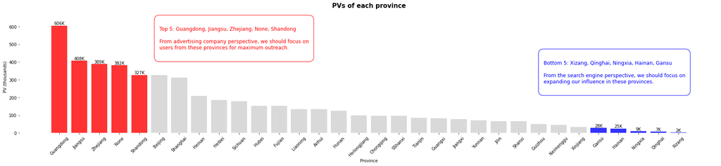

#### Count the PVs of each UA, and plot it with a **pie chart** (show the percentages in the chart).

|  | UA | PV |
| --- | --- | --- |
| 0 | Chrome | 2826199 |
| 1 | Firefox | 117313 |
| 2 | MSIE 6.0 | 99459 |
| 3 | MSIE 7.0 | 247938 |
| 4 | MSIE 8+ | 516059 |
| 5 | MSIE 8.0 | 759051 |
| 6 | Others | 291196 |
| 7 | Safari | 104711 |

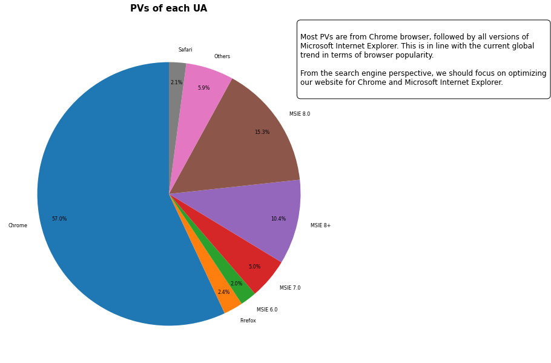

## Qualitative Analysis

#### What are the differences among those charts (How to decide which one to use)

Each of the chart has their purpose and analysis can be derived from them (please refer to the markdown analysis or in-diagram analysis for each chart above). The usage choice of the charts depends largely on the purpose and intent of the report, as well as from whose perspective.

For instance, if the report is meant to be submitted to the search engine company to call for a review of their infrastructure to reduce latency, then the following chart would be important:

1. **Chart 1 and 2 on average SRT and its components**

   These illustrate the distribution of network latency amongst users and is useful to benchmark the search engine performance (e.g. 99th percentile of all queries are under the ideal SRT)
3. **Chart 4 on CDF of #Images**

   This could be useful if we are inspecting deep into the cause of latency and when deciding on the choice of optimisation algorithms. For example, if Algorithm A results in lower latency (e.g. on Tserver) but would have the side effect of being unable to service many embedded images, the chart can be used to determine what is our "Service Level Agreement".
4. **Chart 5 on PVs per minute**

   This is important since the PVs per minute could influence both the Tnet (network bandwidth) and Tserver (CPU utilisation). Being able to redesign the infrastructure and algorithms around this would be handy in optimising cost and performance.
5. **Chart 6 on province**

   This can be helpful to determine which provinces to improve the infrastructure first. For example, the top 5 provinces of PVs should be improved first to service more users.
6. **Chart 7 on UA**

   This is helpful to determine which browser to optimise our search engine on first. For example, the top browser (Chrome) should have priority when we redesign our search engine application.

On the other hand, if the report is meant to be submitted to advertising agencies / companies to maximum advertisement outreach, a different set of chart would be important:

1. **Chart 6 on province**

   This is critical to understand which province do most of the traffic / users come from. With this, advertising can be more targetted. For example, clients targetting the top5 provinces in terms of PVs should engage with advertising / marketing deals with the search engine.
2. **Chart 7 on UA**

   If the adverising agency wish to launch a Chrome extension to help users automatically look for the cheapest deals or apply a voucher, this pie chart would be able to justify their approach.

**Alternative Interpretation:**

- **Line chart**: A line chart displays data points connected by lines, making it useful for plotting continuous variables over time, such as search response time (SRT) or the number of page views. It can help identify trends and patterns in the data over time, which can be useful for identifying performance issues or measuring the impact of changes made to the search engine.
- **Stacked area chart**: A stacked area chart displays the cumulative total of multiple series on top of each other, making it useful for visualizing the contribution of multiple factors to a single variable, such as the four components of SRT. It can help identify which factors are contributing the most to the overall performance of the search engine, which can be useful for prioritizing improvements.
- **100% stacked area chart**: Similar to a stacked area chart, a 100% stacked area chart shows the composition of different categories over time, but it represents the data as a percentage of the whole. This chart is best used when you want to compare the relative proportion of each category over time.
- **CDF chart**: A CDF (cumulative distribution function) chart is useful for visualizing the distribution of a continuous variable, such as SRT per number of images. It is useful in identifying the proportion of searches that fall below a certain threshold, which can be useful for setting performance targets and identifying outliers.
- **Histogram chart**: A histogram chart is a bar chart that displays the distribution of a variable by grouping the data into intervals or bins. It is useful for visualizing the distribution of discrete variables, such as page views by province. For example, a histogram chart can help identify which provinces are generating the most traffic to the search engine, which can be useful for targeting marketing efforts or identifying opportunities for expansion.
- **Pie chart**: A pie chart is a circular chart that shows the proportion of each category in a data set. It is useful for visualizing the relative contribution of discrete variables, such as page views by user agent. For example, a pie chart can help identify which user agents are generating the most traffic to the search engine, which can be useful for optimizing the search engine for different devices or browsers.

#### Describe your experience or findings in doing those jobs. For example, experience of processing the data, observations from the charts, characteristics of the data, potential explanations, and any interesting things you would like to mention.

**Data Preprocessing**

It was interesting to have specified the dtypes for the columns, as it helped to reduce the memory consumption and subsequently, the processing speed of the data.

However, the float64 and float32 dtypes still baffles me as the raw data was only up to 2 decimal places, but float32 failed to represent the data accurately.

**Chart Generation**

In generating the charts, I was considering how to better represent the data and my understanding of the charts. Eventually, I did so in a few ways:

1. Using distinct colours and flushing certain portions of the chart to the background to draw attention to the important components
2. Adding additional data labels (such as vertical lines and labelling the x-values / x-ticks) to the graph and pie chart
3. Shading the area to indicate density and "area under curve" concept for the "Service Level Agreement" / percentile analysis
4. Applying smoothen to some graphs to derive a slightly different analysis and avoid distractions
5. Placing 2 graphs side-by-side for easier comparison (such as the PDF and CDF)
6. Markdown text explaining my analysis of the charts
7. Adding text in the graphs to highlight the conclusions
8. Exploring different libraries to achieve similar graphical outputs (such as comparing sns.distplot with matplotlib in terms of both visuals and time performance)

**Chart Observations**

It was interesting to observe that most of the User Agents were that of a Chrome browser. According to news, Google services such as the Chrome browser have not been available to mainland China users since 2014. This is in contrast with the analysis derived from the logs.

On a side note, chart 2 seems to suggest that the SRT components could be correlated. This could be due to the fact that a high network latency suggests that there are many incoming requests, which would also stress the CPU of the servers and cause other side effects. Therefore, both Tnet and Tserver would fluctuate together.

**Alternative Interpretation:**